# Intro to CDA: Missing Data

1/26/2020

## What is missing data?

## Missing data

- Unit-nonresponse and item-nonresponse (main reasons)
- We have \(Y=(Y_1, Y_2,..., Y_n)\) with \(Y_{obs}=(Y_1,Y_2,...,Y_l)\) and \(Y_{miss}=(Y_{l+1},Y_{l+2},...,Y_n)\)
- We want to estimate some parameter like the mean \[\mu = \mathbb{E}(Y_i)=\mathbb{E}(Y)\]
- If missing data is purely random, then \(\mathbb{E}(Y_{obs})=\mathbb{E}(Y_{miss})=\mu\), but this is almost never the case!

## Solutions?

## Previous Ideas…

- Case or list-wise deletion (loss of a large amount of data)
- Reweighting…
- Modeling the missingness directly (as in SEM)
- *Single imputation* (each missing value substituted by \(\bar{y}_{obs}\), or predictions from a regression model, or the last observation carried forward method)
- Hot deck (matching, plus some sort of random sampling) or stochastic regression imputation (prediction plus some noise)

## Why these other approaches fail?

- These methods *tend to bias estimators and their variance!!!!*
- Mean imputation and (unconditional) hot deck imputation can be very harmful for multivariate estimates
- Regression imputation accounts for multivariate dependencies, but exaggerates the association between variables
- Simple Hot Deck does not account for associations among variables
- Best way is stochastic regression imputation, but underestimate the variance

## Multiple Imputation

## Principle

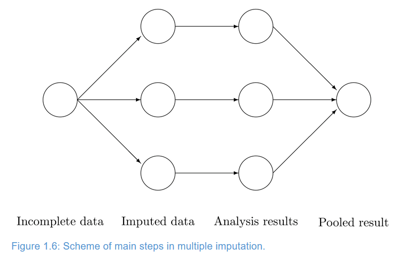

- Taken from the book “Flexible Imputation of Missing Data” by Stef Van Buuren [here!](https://stefvanbuuren.name/fimd/sec-nutshell.html)

## The Idea

- We need a sampling function that represents uncertainty (randomness) generated by the missingness
- Goal: *adjustment of the variance of our estimator*

## Randomness

- Missingness is a type probabilistic event
- \(Y=(Y_{obs},Y_{miss})\) and they have a joint distribution \(f(y_i; \theta)=f(y_{obs},y_{miss}; \theta)\) for each observation \(i \in Y\)

## Missing mechanisms I

- \(R_{ij} \in \{0,1\}\) if unobserved or observed for variable \(Y_j\) and observation \(i\).
- Its distribution depends on some unknown parameters \(f(r,\xi)\)
- Joint distribution of \(Y\) and \(R\): \[f(y,r;\theta,\xi)=f(y;\theta)f(r|y;\xi,\theta)\]

## Missing mechanisms II

- Missing completely at random: \(f(r|y;\xi)=f(r|y_{obs},y_{mis};\xi)=f(r;\xi)\)
- Missing at random: \(f(r|y;\xi)=f(r|y_{obs},y_{mis};\xi)=f(r|y_{obs};\xi)\)
- Not missing at random (NMAR): \(f(r|y;\xi)=f(r|y_{obs},y_{mis};\xi)\)
- A pattern can look like is non-random, but the mechanism might still be MCAR!

## Principle of MI I

- If we had complete data, then we can say our estimates are normally distributed \[(\hat{\theta} - \theta) \sqrt{var(\hat{\theta})} \sim \mathcal{N}(0,1)\]
- We are going to make \(m=1,2,....,M\) complete data sets through some *model*
- For each of the \(M\) complete data sets we estimate both: \(\hat{\theta}^{(m)}\) and \(\hat{var}(\hat{\theta}^{(m)})\)

## Principle of MI II

From those we can obtain:

- *multiple imputation estimator* \[\hat{\theta}_{MI}=\frac{1}{M}\sum_{m=1}^M \hat{\theta}^{(m)}\]
- *estimated variance* \[T=W+(1+\frac{1}{M})B\] where \(W=\frac{1}{M}\sum_{m=1}^M \hat{var}(\hat{\theta}^{(m)})\) is the within-imputation variance and \(B=\frac{1}{M-1}\sum_{m=1}^M (\hat{\theta}^{(m)}-\hat{\theta}_{MI})^2\) is the between imputation variance

## Principle of MI III

- And additionally, the fraction of missing information for our scalar parameter \(\theta_p\): \[\gamma = \frac{r+2/(v+3)}{1+r}\] where \(r=\frac{(1+M^{-1})B}{W}\) is the relative increase in variance do to missingness

## Principle of MI IV

- We want to estimate: \(\mathbb{E}(\Theta | y_{obs})\)
- From the posterior predictive distributions \(f(Y_{miss}|Y_{obs})\), we get imputed data \(m=1,2,...,M\)
- So that we have an estimator \(\hat{\theta}^{(m)}\) which is a function of the observed and imputed values! \[\hat{\theta}^{(m)}=\hat{\theta}(Y_{obs},Y_{miss}) \approx \mathbb{E}(\Theta | y_{obs}, Y_{miss})\]
- What can be shown is that for \(M \rightarrow \infty\): \[\hat{\theta}_{MI} \rightarrow \mathbb{E}(\Theta | Y_{obs})\]

## When is MI needed?

- If interest is in inferential statistics, then we need MI
- To obtain Confidence Intervals
- To carry on Hypothesis Testing
- To find out about how uncertain our model is

### When MI is not needed?

- For basic descriptives!
- Computing contingency tables, correlations, means, etc.

## Assumptions

- We assumte data are Missing At Random (MAR)

If is not true…

- And if causes of missingness are strongly correlated with outcomes
- We have a problem…
- But, it is the best thing that we can do still

## Algorithm

- We will only cover the fully conditional specification (FCS) or multivariate imputation by chained equations (MICE)

## Pseudo-algorithm

Say we want to impute our missings for variables \(Y_j\)

- Step 1. Specify a model: \(P(Y_j^{mis}|Y_j^{obs},Y_{[-j]},R)\)
- Step 2. For each variable \(j\), we randomly take draws from the observed values in \(Y_j^{obs}\) for starting imputation
- Step 3. We repeat this \(t\) times, where \(t=1,2,...,T\) iterations
- Step 4. And for all variables with missing \(j=1,...,p\), we start with variable \(j\)
- Step 5. If we define \(\dot{Y_j}=(\dot{Y_1}^t,...,\dot{Y}_{j-1}^t,\dot{Y_1}^{t-1},...,\dot{Y}_{j-1}^{t-1})\) as a at iteration \(t\) complete data
- Step 6. We can draw the vector \(\dot{\phi_j}^t \sim P(\phi_j^t|Y_j^{obs},\dot{Y}_{[-j]}^t,R)\) of parameters that determine the multivariate distribution of \(Y\) from which we will draw the imputed values
- Step 7. And then draw the imputations \(\dot{Y}_j^t \sim P(Y_j^{mis}|Y_j^{obs},\dot{Y}_{[-j]}^t,R,\dot{\phi}_j^t)\)
- Step 8. End the repetition for \(j\)
- Step 9. End the repetition for \(t\)

## Practical advice I

- \(m\): number of imputations should be similar to the percentage of cases that are incomplete
- 10-20 iterations is enough
- Use as much information as available (including all variables in the analysis)
- Include information that is suspected to be related to the missing mechanism

## Practical advice II

- Include variables which explain a lot of the variance (most important variables in any given analysis)
- Remove variables with a too high proportion of missing (80% or higher)
- Passive imputation
- Conditional imputation
- Problems when pooling the analysis
- Combination rules do not hold for non-normal estimators!(BIG PROBLEM)

## Let’s go to R

## Things left out…

- Not normally distributed estimators?
- Multilevel data?
- Incorporation of survey weights?
- NMAR?

## And remember…

## DO NOT IMPUTE ONLY ONCE!!!!!

## Next on CDA

- Ploting and more Rmarkdown!

### To read

- [ggplot2](https://ggplot2-book.org/)